# Police Killings in Western U.S. During 2015

Kelsey Graczyk, Cydni Mullikin, and Tia Kinilau

2017-04-04

This vignette is based on data collected for the 538 story entitled “Where Police Have Killed Americans in 2015” by Ben Casselman available [here](https://fivethirtyeight.com/features/where-police-have-killed-americans-in-2015/).

First, we load the required packages to reproduce the analysis.

```r
library(fivethirtyeight)
library(dplyr)
library(ggplot2)
library(readr)
library(knitr)
library(ggthemes)
```

*It is important to note that the data used in our graphs come from the Western states, which include: Oregon, Washington, Idaho, Montana, Wyoming, California, Hawaii, Alaska, Colorado, New Mexico, Utah, Arizona, and Nevada. These graphs do not represent the entire United States. Our data only represents the population proportions of the people in the Western portion of the United States.*

## Filter the data frame to only the Western U.S.

The data frame shown comes from the `fivethirtyeight` package using the `police_killings` data set. This original data frame both includes and focuses on where– state, city, longitude/latitude, and street address– and how the killings occurred by police officers in the U.S. in the year 2015. The `police_killings_final` data frame that we created filters out only the western portion of the United States and specifies the variables of race/ethnicity, cause of death, armed, and age in order to focus on our interests.

```r
west_states <- c("OR", "WA", "ID", "MT", "WY", "CA", "HI", "AK", "CO", "NM", "UT", "AZ", "NV")
police_killings_final <- police_killings %>%
  filter(state %in% west_states) %>%
  select(raceethnicity, cause, armed, age)
```

## Group by cause of death and armed

This data frame takes the data from `police_killings_final` and summarizes the total count based off the cause of death as well as the type of weapon the victim was armed with, if any at all. The “count” in this data frame refers to the number of people that fit the specific criteria of each category. The inclusion of `tidyr::complete` was made in order to have the bars in the plot that follows be of the same width.

```r
police_complete <- police_killings_final %>%
  group_by(cause, armed) %>%
  summarize(count = n()) %>%
  ungroup() %>%
  tidyr::complete(cause, armed, fill = list(count = 0))
police_complete
```

| cause | armed | count |
| --- | --- | --- |
| Death in custody | Disputed | 0 |
| Death in custody | Firearm | 1 |
| Death in custody | Knife | 3 |
| Death in custody | No | 2 |
| Death in custody | Non-lethal firearm | 0 |
| Death in custody | Other | 0 |
| Death in custody | Vehicle | 0 |
| Gunshot | Disputed | 1 |
| Gunshot | Firearm | 74 |
| Gunshot | Knife | 23 |
| Gunshot | No | 27 |
| Gunshot | Non-lethal firearm | 6 |
| Gunshot | Other | 5 |
| Gunshot | Vehicle | 6 |
| Struck by vehicle | Disputed | 0 |
| Struck by vehicle | Firearm | 2 |
| Struck by vehicle | Knife | 1 |
| Struck by vehicle | No | 0 |
| Struck by vehicle | Non-lethal firearm | 0 |
| Struck by vehicle | Other | 0 |
| Struck by vehicle | Vehicle | 0 |
| Taser | Disputed | 0 |
| Taser | Firearm | 4 |
| Taser | Knife | 0 |
| Taser | No | 1 |
| Taser | Non-lethal firearm | 0 |
| Taser | Other | 0 |
| Taser | Vehicle | 0 |

## Relationship between the cause of death and victims being armed

For this plot we wondered what it would look like if we compared the causes of death from a police officer with the type of weapon the victims were armed with, if at all.

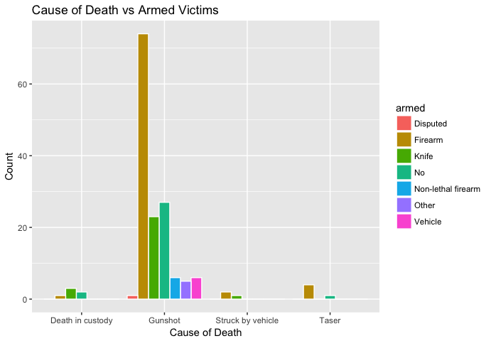

```r
police_complete <- police_killings_final %>%
  group_by(cause, armed) %>%
  summarize(count = n()) %>%
  ungroup() %>%
  tidyr::complete(cause, armed, fill = list(count = 0))
ggplot(data = police_complete,
       mapping = aes(x = cause, y = count))+
  geom_col(aes(fill = armed), position = "dodge", color = "white") +
  labs(x = "Cause of Death", y = "Count", title = "Cause of Death vs Armed Victims")
```

### Now let’s take a zoomed-in look at deaths caused by gunshot

From the previous graph, it was apparent that the most prevalent cause of death was by gunshot. We decided to give you a better look at the people and what types of weapons they were armed with, if any.

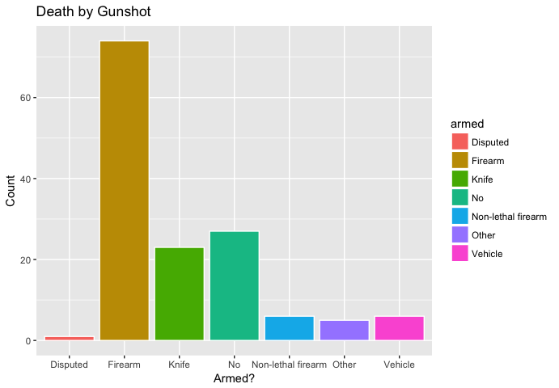

```r
police_zoom <- police_killings_final %>%
  filter( cause == "Gunshot")
ggplot(data = police_zoom, mapping = aes(x = armed)) +
  geom_bar(position = "dodge", color = "white", aes(fill = armed))+
  labs(x = "Armed?", y = "Count", title = "Death by Gunshot" )
```

This graph shows us that those who were killed by gunshot were mostly armed with a firearm. Although this graph serves as a visual representation, it does not give a numerical summary of the data. Below, we created a table that depicts this data more in depth.

### Now let’s take a look at the proportion of those killed by gunshot

This data frame focuses on those who were killed by gunshot. It displays the actual proportions of the different weapons carried by those who were shot.

```r
police_proportion <- police_killings_final %>%
  filter( cause == "Gunshot") %>%
  group_by(armed) %>%
  summarize( count = n()) %>%
  mutate(prop = count / sum(count))
police_proportion
```

| armed | count | prop |
| --- | --- | --- |
| Disputed | 1 | 0.0070423 |
| Firearm | 74 | 0.5211268 |
| Knife | 23 | 0.1619718 |
| No | 27 | 0.1901408 |
| Non-lethal firearm | 6 | 0.0422535 |
| Other | 5 | 0.0352113 |
| Vehicle | 6 | 0.0422535 |

From this data frame, we can see that more than 50% of those who were killed by gunshot were also carrying a firearm, while about 20% were not armed at all.

## Now let’s see how race/ethnicity ties in with our previous findings

For this plot, we wondered what it would look like if we compared the causes of death with the races/ethnicities of those who were killed by police officers. We also used the `na.omit` function to exclude all rows that had entries with missing `NA` values.

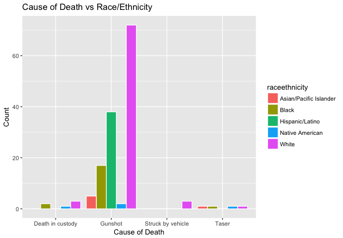

```r
police_killings_omit <- police_killings_final %>%
  na.omit() %>%
  group_by(cause, raceethnicity) %>%
  summarize(count = n()) %>%
  ungroup() %>%
  tidyr::complete(cause, raceethnicity, fill = list(count = 0))
ggplot(data = police_killings_omit,
       mapping = aes(x = cause, y = count)) +
  geom_col(aes(fill = raceethnicity), position = "dodge", color = "white") +
  labs(x = "Cause of Death", y = "Count", title = "Cause of Death vs Race/Ethnicity")
```

## Focus on race/ethnicity within the gunshot variable

For this plot, we decided to focus on the races/ethnicities of the victims who were killed by gunshot because this category had the most prominent number of individuals.

```r
police_zoom_RE <- police_killings_final %>%
  na.omit() %>%
  filter(cause == "Gunshot")
```

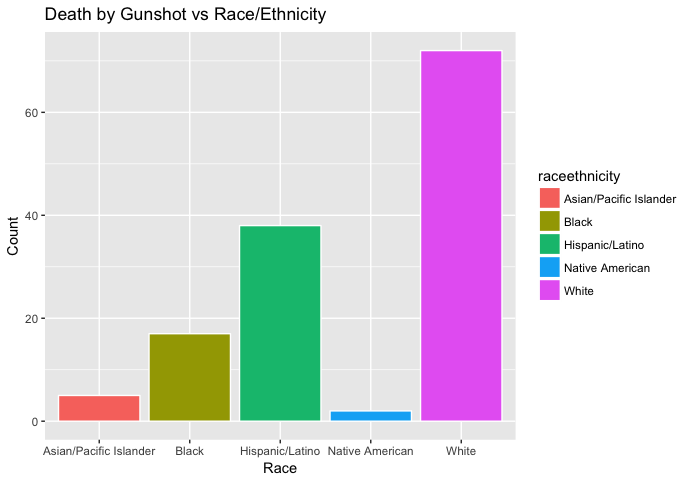

```r
ggplot(data = police_zoom_RE, mapping = aes(x = raceethnicity)) +
  geom_bar(aes(fill = raceethnicity), position = "dodge", color = "white") +
  labs(x = "Race", y = "Count", title = "Death by Gunshot vs Race/Ethnicity")
```

This graphic displays that white people have the highest count of deaths by gunshot, followed by Hispanics/Latinos and then African Americans. The two lowest counts came from Asians/Pacific Islanders as well as Native Americans. While it shows that more white people were killed by gunshot in the U.S. in 2015, it is also the case that whites make up the vast majority of the Western Region of the United States.

## Concluding thoughts

*We also looked up the demographics of the Western U.S. in order to get a better understanding of the data being displayed. On the Kaiser Family Foundation website, we found proportions of races/ethnicities in the Western U.S. that corresponded to the information we mentioned earlier.*